# HIV Testing Analysis in PROSPECT Study

Analysis of HIV testing outcomes in PROSPECT Study

Peter MacPherson Liverpool School of Tropical Medicine, Liverpool, UK Malawi-Liverpool-Wellcome Clinical Research Programme, Blantyre, Malawi

May 24, 2019 Table of Contents:

## 2. Set-up

Load all required packages for analysis.

## 3. Import datasets

Import data required for the analysis.

```r
data("entry", package = "hiv.prospect")
data("exit", package = "hiv.prospect")
```

## 4. Characteristics of attenders

In total, between 15th May 2018 and 7th September 2018 inclusive, there were a total of 5422 adult acute attendances at the study clinic (Bangwe Health Centre, Blantyre, Malawi).

What proportion of attendances were repeat attendances during the study period?

```r
entry %>%
  tabyl(reattendance) %>%
  kable(digits = 3, caption = "Proportion of attendances that were repeat")
```

Proportion of attendances that were repeat

| reattendance | n | percent |
| --- | --- | --- |
| 0 | 4895 | 0.903 |
| 1 | 527 | 0.097 |

What was the distribution of multiple visits by participants?

```r
entry %>%
  group_by(case_id) %>%
  mutate(sum_visits = sum(reattendance)+1) %>%
  tabyl(sum_visits) %>%
  kable(digits = 3, caption = "Distribution of visits")
```

Distribution of visits

| sum_visits | n | percent |
| --- | --- | --- |
| 1 | 4447 | 0.820 |
| 2 | 780 | 0.144 |
| 3 | 135 | 0.025 |
| 4 | 32 | 0.006 |
| 5 | 15 | 0.003 |
| 6 | 6 | 0.001 |
| 7 | 7 | 0.001 |

What was the distribution of clinic visits by day?

```r
entry %>%
  group_by(received_on) %>%
  mutate(dailycount = n()) %>%
  summarise(dailymean = mean(dailycount)) %>%
  summarise(mean = mean(dailymean),
            min = min(dailymean),
            max = max(dailymean),
            median = median(dailymean))
```

```
## # A tibble: 1 x 4
##    mean   min   max median
##   <dbl> <dbl> <dbl>  <dbl>
## 1  70.4    41   106     69
```

Does the distribution of visits vary by characteristics (sex, cough, any TB symptoms?)

```r
entry %>%
  group_by(case_id) %>%
  mutate(sum_visits = sum(reattendance)+1) %>%
  tabyl(sum_visits, sex) %>%
  adorn_totals("col") %>%
  adorn_totals("row") %>%
  adorn_percentages("col") %>%
  adorn_pct_formatting() %>%
  adorn_ns() %>%
  kable(digits = 3, caption = "Distribution of visits by sex")
```

Distribution of visits by sex

| sum_visits | Female | Male | Total |
| --- | --- | --- | --- |
| 1 | 81.5% (2840) | 83.0% (1607) | 82.0% (4447) |
| 2 | 14.7% (514) | 13.7% (266) | 14.4% (780) |
| 3 | 2.7% (93) | 2.2% (42) | 2.5% (135) |
| 4 | 0.5% (16) | 0.8% (16) | 0.6% (32) |
| 5 | 0.3% (10) | 0.3% (5) | 0.3% (15) |
| 6 | 0.2% (6) | 0.0% (0) | 0.1% (6) |
| 7 | 0.2% (7) | 0.0% (0) | 0.1% (7) |
| Total | 100.0% (3486) | 100.0% (1936) | 100.0% (5422) |

```r
entry %>%
  group_by(case_id) %>%
  mutate(sum_visits = sum(reattendance)+1) %>%
  tabyl(sum_visits, cough) %>%
  adorn_totals("col") %>%
  adorn_totals("row") %>%
  adorn_percentages("col") %>%
  adorn_pct_formatting() %>%
  adorn_ns() %>%
  kable(digits = 3, caption = "Distribution of visits by cough status")
```

Distribution of visits by cough status

| sum_visits | No | Yes | Total |
| --- | --- | --- | --- |
| 1 | 81.8% (2944) | 82.5% (1503) | 82.0% (4447) |
| 2 | 14.6% (524) | 14.1% (256) | 14.4% (780) |
| 3 | 2.2% (80) | 3.0% (55) | 2.5% (135) |
| 4 | 0.9% (31) | 0.1% (1) | 0.6% (32) |
| 5 | 0.4% (14) | 0.1% (1) | 0.3% (15) |
| 6 | 0.2% (6) | 0.0% (0) | 0.1% (6) |
| 7 | 0.1% (2) | 0.3% (5) | 0.1% (7) |
| Total | 100.0% (3601) | 100.0% (1821) | 100.0% (5422) |

```r
entry %>%
  group_by(case_id) %>%
  mutate(sum_visits = sum(reattendance)+1) %>%
  tabyl(sum_visits, any_symptoms) %>%
  adorn_totals("col") %>%
  adorn_totals("row") %>%
  adorn_percentages("col") %>%
  adorn_pct_formatting() %>%
  adorn_ns() %>%
  kable(digits = 3, caption = "Distribution of visits by presence of any TB symptoms")
```

Distribution of visits by presence of any TB symptoms

| sum_visits | FALSE | TRUE | Total |
| --- | --- | --- | --- |
| 1 | 80.1% (1928) | 83.5% (2519) | 82.0% (4447) |
| 2 | 15.5% (374) | 13.5% (406) | 14.4% (780) |
| 3 | 2.5% (60) | 2.5% (75) | 2.5% (135) |
| 4 | 1.1% (27) | 0.2% (5) | 0.6% (32) |
| 5 | 0.5% (13) | 0.1% (2) | 0.3% (15) |
| 6 | 0.1% (2) | 0.1% (4) | 0.1% (6) |
| 7 | 0.1% (2) | 0.2% (5) | 0.1% (7) |
| Total | 100.0% (2406) | 100.0% (3016) | 100.0% (5422) |

Now make a table of characteristics of attendance episodes

```r
table1 <- tableby(sex ~
                  age +
                  cough +
                  weight_loss +
                  fever +
                  night_sweats +
                  any_symptoms +
                  chronic_cough +
                  blantyre_res +
                  tb_rx +
                  tb_rx_6m,
                  data = entry,
                test = FALSE,
                numeric.stats = c("medianrange"))

kable(summary(table1), caption = "Table 1: Characteristics of attendance episodes by sex")
```

Table 1: Characteristics of attendance episodes by sex

|  | Female (N=3486) | Male (N=1936) | Total (N=5422) |
| --- | --- | --- | --- |
| **age** |  |  |  |
| Median (Range) | 28.000 (18.000, 88.000) | 28.000 (18.000, 89.000) | 28.000 (18.000, 89.000) |
| **cough** |  |  |  |
| No | 2351 (67.4%) | 1250 (64.6%) | 3601 (66.4%) |
| Yes | 1135 (32.6%) | 686 (35.4%) | 1821 (33.6%) |
| **weight_loss** |  |  |  |
| No | 3055 (87.6%) | 1655 (85.5%) | 4710 (86.9%) |
| Yes | 431 (12.4%) | 281 (14.5%) | 712 (13.1%) |
| **fever** |  |  |  |
| No | 2535 (72.7%) | 1306 (67.5%) | 3841 (70.8%) |
| Yes | 951 (27.3%) | 630 (32.5%) | 1581 (29.2%) |
| **night_sweats** |  |  |  |
| No | 2890 (82.9%) | 1548 (80.0%) | 4438 (81.9%) |
| Yes | 596 (17.1%) | 388 (20.0%) | 984 (18.1%) |
| **any_symptoms** |  |  |  |
| FALSE | 1581 (45.4%) | 825 (42.6%) | 2406 (44.4%) |
| TRUE | 1905 (54.6%) | 1111 (57.4%) | 3016 (55.6%) |
| **chronic_cough** |  |  |  |
| FALSE | 3182 (91.3%) | 1718 (88.7%) | 4900 (90.4%) |
| TRUE | 304 (8.7%) | 218 (11.3%) | 522 (9.6%) |
| **blantyre_res** |  |  |  |
| N-Miss | 2351 | 1250 | 3601 |
| No | 29 (2.6%) | 16 (2.3%) | 45 (2.5%) |
| Yes | 1106 (97.4%) | 670 (97.7%) | 1776 (97.5%) |
| **tb_rx** |  |  |  |
| N-Miss | 2351 | 1250 | 3601 |
| No | 1087 (95.8%) | 657 (95.8%) | 1744 (95.8%) |
| Yes | 48 (4.2%) | 29 (4.2%) | 77 (4.2%) |
| **tb_rx_6m** |  |  |  |
| N-Miss | 2351 | 1250 | 3601 |
| No | 1107 (97.5%) | 677 (98.7%) | 1784 (98.0%) |
| Yes | 28 (2.5%) | 9 (1.3%) | 37 (2.0%) |

##5. Comparison of characteristics of those who did and did not undergo exit interview

First merge the datasets together - need to be careful to merge on participant id as well as date of attendance so as to match unique attendences among people who reattended.

```r
exit <- exit %>% mutate(interviewed = "Interviewed")

merged <- left_join(entry, exit, by = c("case_id", "received_on"))

merged <- merged %>%
  mutate(interviewed = case_when(is.na(interviewed) ~ "Not interviewed",
                                 TRUE ~ interviewed))

table2 <- tableby(interviewed ~
                  sex +
                  age +
                  cough +
                  weight_loss +
                  fever +
                  night_sweats +
                  any_symptoms +
                  chronic_cough +
                  blantyre_res +
                  tb_rx +
                  tb_rx_6m,
                  data = merged,
                test = FALSE,
                numeric.stats = c("medianrange"),
                cat.stats = "countrowpct")

kable(summary(table2), caption = "Table 2: Comparison between participants who were and were not exit interviewed")
```

Table 2: Comparison between participants who were and were not exit interviewed

|  | Interviewed (N=2397) | Not interviewed (N=3025) | Total (N=5422) |
| --- | --- | --- | --- |
| **sex** |  |  |  |
| Female | 1497 (42.9%) | 1989 (57.1%) | 3486 (100.0%) |
| Male | 900 (46.5%) | 1036 (53.5%) | 1936 (100.0%) |
| **age** |  |  |  |
| Median (Range) | 28.000 (18.000, 89.000) | 27.000 (18.000, 89.000) | 28.000 (18.000, 89.000) |
| **cough** |  |  |  |
| No | 1548 (43.0%) | 2053 (57.0%) | 3601 (100.0%) |
| Yes | 849 (46.6%) | 972 (53.4%) | 1821 (100.0%) |
| **weight_loss** |  |  |  |
| No | 2081 (44.2%) | 2629 (55.8%) | 4710 (100.0%) |
| Yes | 316 (44.4%) | 396 (55.6%) | 712 (100.0%) |
| **fever** |  |  |  |
| No | 1663 (43.3%) | 2178 (56.7%) | 3841 (100.0%) |
| Yes | 734 (46.4%) | 847 (53.6%) | 1581 (100.0%) |
| **night_sweats** |  |  |  |
| No | 1936 (43.6%) | 2502 (56.4%) | 4438 (100.0%) |
| Yes | 461 (46.8%) | 523 (53.2%) | 984 (100.0%) |
| **any_symptoms** |  |  |  |
| FALSE | 1027 (42.7%) | 1379 (57.3%) | 2406 (100.0%) |
| TRUE | 1370 (45.4%) | 1646 (54.6%) | 3016 (100.0%) |
| **chronic_cough** |  |  |  |
| FALSE | 2176 (44.4%) | 2724 (55.6%) | 4900 (100.0%) |
| TRUE | 221 (42.3%) | 301 (57.7%) | 522 (100.0%) |
| **blantyre_res** |  |  |  |
| No | 24 (53.3%) | 21 (46.7%) | 45 (100.0%) |
| Yes | 825 (46.5%) | 951 (53.5%) | 1776 (100.0%) |
| **tb_rx** |  |  |  |
| No | 809 (46.4%) | 935 (53.6%) | 1744 (100.0%) |
| Yes | 40 (51.9%) | 37 (48.1%) | 77 (100.0%) |
| **tb_rx_6m** |  |  |  |
| No | 830 (46.5%) | 954 (53.5%) | 1784 (100.0%) |
| Yes | 19 (51.4%) | 18 (48.6%) | 37 (100.0%) |

##6. Analysis of outcome

First how many were on ART? These will need to be filtered out as they are not eligibile for offer of HIV test

```r
merged %>% tabyl(art) %>% kable()
```

| art | n | percent | valid_percent |
| --- | --- | --- | --- |
| No | 2121 | 0.3911841 | 0.8848561 |
| Yes | 276 | 0.0509037 | 0.1151439 |
| NA | 3025 | 0.5579122 | NA |

```r
outdata <- merged %>%
  filter(interviewed =="Interviewed") %>%
  filter(art == "No")
```

Now, of those remaining, how many are HIV-positive, but not on ART (these should be eligible for HIV testing)

```r
outdata %>% tabyl(hivstatus) %>% kable()
```

| hivstatus | n | percent |
| --- | --- | --- |
| Negative | 1809 | 0.8528996 |
| Never tested/don’t know | 296 | 0.1395568 |
| Positive | 16 | 0.0075436 |

Now look at what proportion was offered HIV testing

```r
outdata %>% tabyl(askhivtest) %>% kable()
```

| askhivtest | n | percent |
| --- | --- | --- |
| No | 1536 | 0.7241867 |
| Yes | 585 | 0.2758133 |

And what proportion actually did report HIV testing on same day?

```r
outdata %>% tabyl(testedhiv) %>% kable()
```

| testedhiv | n | percent |
| --- | --- | --- |
| No | 1666 | 0.7854785 |
| Yes | 455 | 0.2145215 |

Compare characteristics between those offered and not offered HIV testing.

```r
table3 <- tableby(askhivtest ~
                  sex +
                  age +
                  cough +
                  weight_loss +
                  fever +
                  night_sweats +
                  any_symptoms +
                  chronic_cough +
                  srh +
                  blantyre_res +
                  tb_rx +
                  tb_rx_6m +
                  prevtb +
                  everhivtest +
                  lasthivresult +
                  hivstatus,
                  data = merged,
                test = FALSE,
                numeric.stats = c("medianrange"),
                cat.stats = "countrowpct")

kable(summary(table3), caption = "Table 3: Comparison between participants who were and were not offered HIV testing during clinic attendance")
```

Table 3: Comparison between participants who were and were not offered HIV testing during clinic attendance

|  | No (N=1809) | Yes (N=588) | Total (N=2397) |
| --- | --- | --- | --- |
| **sex** |  |  |  |
| Female | 1153 (77.0%) | 344 (23.0%) | 1497 (100.0%) |
| Male | 656 (72.9%) | 244 (27.1%) | 900 (100.0%) |
| **age** |  |  |  |
| Median (Range) | 29.000 (18.000, 89.000) | 26.000 (18.000, 87.000) | 28.000 (18.000, 89.000) |
| **cough** |  |  |  |
| No | 1172 (75.7%) | 376 (24.3%) | 1548 (100.0%) |
| Yes | 637 (75.0%) | 212 (25.0%) | 849 (100.0%) |
| **weight_loss** |  |  |  |
| No | 1567 (75.3%) | 514 (24.7%) | 2081 (100.0%) |
| Yes | 242 (76.6%) | 74 (23.4%) | 316 (100.0%) |
| **fever** |  |  |  |
| No | 1266 (76.1%) | 397 (23.9%) | 1663 (100.0%) |
| Yes | 543 (74.0%) | 191 (26.0%) | 734 (100.0%) |
| **night_sweats** |  |  |  |
| No | 1453 (75.1%) | 483 (24.9%) | 1936 (100.0%) |
| Yes | 356 (77.2%) | 105 (22.8%) | 461 (100.0%) |
| **any_symptoms** |  |  |  |
| FALSE | 788 (76.7%) | 239 (23.3%) | 1027 (100.0%) |
| TRUE | 1021 (74.5%) | 349 (25.5%) | 1370 (100.0%) |
| **chronic_cough** |  |  |  |
| FALSE | 1628 (74.8%) | 548 (25.2%) | 2176 (100.0%) |
| TRUE | 181 (81.9%) | 40 (18.1%) | 221 (100.0%) |
| **srh** |  |  |  |
| Fair | 684 (79.3%) | 179 (20.7%) | 863 (100.0%) |
| Good | 1038 (73.7%) | 371 (26.3%) | 1409 (100.0%) |
| Poor/Very_poor | 34 (69.4%) | 15 (30.6%) | 49 (100.0%) |
| very_good | 53 (69.7%) | 23 (30.3%) | 76 (100.0%) |
| **blantyre_res** |  |  |  |
| No | 19 (79.2%) | 5 (20.8%) | 24 (100.0%) |
| Yes | 618 (74.9%) | 207 (25.1%) | 825 (100.0%) |
| **tb_rx** |  |  |  |
| No | 600 (74.2%) | 209 (25.8%) | 809 (100.0%) |
| Yes | 37 (92.5%) | 3 (7.5%) | 40 (100.0%) |
| **tb_rx_6m** |  |  |  |
| No | 622 (74.9%) | 208 (25.1%) | 830 (100.0%) |
| Yes | 15 (78.9%) | 4 (21.1%) | 19 (100.0%) |
| **prevtb** |  |  |  |
| No | 1685 (74.7%) | 571 (25.3%) | 2256 (100.0%) |
| Yes | 124 (87.9%) | 17 (12.1%) | 141 (100.0%) |
| **everhivtest** |  |  |  |
| No | 168 (78.5%) | 46 (21.5%) | 214 (100.0%) |
| Yes | 1641 (75.2%) | 542 (24.8%) | 2183 (100.0%) |
| **lasthivresult** |  |  |  |
| Dont_know | 63 (88.7%) | 8 (11.3%) | 71 (100.0%) |
| Negative | 1342 (71.6%) | 532 (28.4%) | 1874 (100.0%) |
| Nevertested | 118 (72.4%) | 45 (27.6%) | 163 (100.0%) |
| Positive | 286 (99.0%) | 3 (1.0%) | 289 (100.0%) |
| **hivstatus** |  |  |  |
| Negative | 1299 (71.7%) | 513 (28.3%) | 1812 (100.0%) |
| Never tested/don’t know | 230 (76.2%) | 72 (23.8%) | 302 (100.0%) |
| Positive | 280 (98.9%) | 3 (1.1%) | 283 (100.0%) |

Compare characteristics between those reporting completing and not completing HIV testing.

```r
table4 <- tableby(testedhiv ~
                  sex +
                  age +
                  cough +
                  weight_loss +
                  fever +
                  night_sweats +
                  any_symptoms +
                  chronic_cough +
                  srh +
                  blantyre_res +
                  tb_rx +
                  tb_rx_6m +
                  prevtb +
                  everhivtest +
                  lasthivresult +
                  hivstatus,
                  data = merged,
                test = FALSE,
                numeric.stats = c("medianrange"),
                cat.stats = "countrowpct")

kable(summary(table4), caption = "Table 4: Comparison between participants who reported completing and not completing HIV testing")
```

Table 4: Comparison between participants who reported completing and not completing HIV testing

|  | No (N=1937) | Yes (N=460) | Total (N=2397) |
| --- | --- | --- | --- |
| **sex** |  |  |  |
| Female | 1231 (82.2%) | 266 (17.8%) | 1497 (100.0%) |
| Male | 706 (78.4%) | 194 (21.6%) | 900 (100.0%) |
| **age** |  |  |  |
| Median (Range) | 29.000 (18.000, 89.000) | 26.000 (18.000, 87.000) | 28.000 (18.000, 89.000) |
| **cough** |  |  |  |
| No | 1260 (81.4%) | 288 (18.6%) | 1548 (100.0%) |
| Yes | 677 (79.7%) | 172 (20.3%) | 849 (100.0%) |
| **weight_loss** |  |  |  |
| No | 1679 (80.7%) | 402 (19.3%) | 2081 (100.0%) |
| Yes | 258 (81.6%) | 58 (18.4%) | 316 (100.0%) |
| **fever** |  |  |  |
| No | 1347 (81.0%) | 316 (19.0%) | 1663 (100.0%) |
| Yes | 590 (80.4%) | 144 (19.6%) | 734 (100.0%) |
| **night_sweats** |  |  |  |
| No | 1557 (80.4%) | 379 (19.6%) | 1936 (100.0%) |
| Yes | 380 (82.4%) | 81 (17.6%) | 461 (100.0%) |
| **any_symptoms** |  |  |  |
| FALSE | 832 (81.0%) | 195 (19.0%) | 1027 (100.0%) |
| TRUE | 1105 (80.7%) | 265 (19.3%) | 1370 (100.0%) |
| **chronic_cough** |  |  |  |
| FALSE | 1748 (80.3%) | 428 (19.7%) | 2176 (100.0%) |
| TRUE | 189 (85.5%) | 32 (14.5%) | 221 (100.0%) |
| **srh** |  |  |  |
| Fair | 721 (83.5%) | 142 (16.5%) | 863 (100.0%) |
| Good | 1125 (79.8%) | 284 (20.2%) | 1409 (100.0%) |
| Poor/Very_poor | 37 (75.5%) | 12 (24.5%) | 49 (100.0%) |
| very_good | 54 (71.1%) | 22 (28.9%) | 76 (100.0%) |
| **blantyre_res** |  |  |  |
| No | 21 (87.5%) | 3 (12.5%) | 24 (100.0%) |
| Yes | 656 (79.5%) | 169 (20.5%) | 825 (100.0%) |
| **tb_rx** |  |  |  |
| No | 639 (79.0%) | 170 (21.0%) | 809 (100.0%) |
| Yes | 38 (95.0%) | 2 (5.0%) | 40 (100.0%) |
| **tb_rx_6m** |  |  |  |
| No | 662 (79.8%) | 168 (20.2%) | 830 (100.0%) |
| Yes | 15 (78.9%) | 4 (21.1%) | 19 (100.0%) |
| **prevtb** |  |  |  |
| No | 1807 (80.1%) | 449 (19.9%) | 2256 (100.0%) |
| Yes | 130 (92.2%) | 11 (7.8%) | 141 (100.0%) |
| **everhivtest** |  |  |  |
| No | 194 (90.7%) | 20 (9.3%) | 214 (100.0%) |
| Yes | 1743 (79.8%) | 440 (20.2%) | 2183 (100.0%) |
| **lasthivresult** |  |  |  |
| Dont_know | 65 (91.5%) | 6 (8.5%) | 71 (100.0%) |
| Negative | 1444 (77.1%) | 430 (22.9%) | 1874 (100.0%) |
| Nevertested | 144 (88.3%) | 19 (11.7%) | 163 (100.0%) |
| Positive | 284 (98.3%) | 5 (1.7%) | 289 (100.0%) |
| **hivstatus** |  |  |  |
| Negative | 1399 (77.2%) | 413 (22.8%) | 1812 (100.0%) |
| Never tested/don’t know | 260 (86.1%) | 42 (13.9%) | 302 (100.0%) |
| Positive | 278 (98.2%) | 5 (1.8%) | 283 (100.0%) |

##7. Statistical modelling

Bayesian regression models

```r
outdata <- as.data.frame(outdata)

outdata <- outdata %>%
  mutate(sex2 = case_when(sex=="Male" ~ 2,
                          sex=="Female" ~ 1)) %>%
  mutate(prevtb2 = case_when(prevtb=="Yes" ~2,
                             prevtb=="No" ~ 1)) %>%
  mutate(everhivtest2 = case_when(everhivtest=="Yes" ~ 2,
                                  everhivtest=="No" ~ 1)) %>%
  mutate(any_symptoms2 = case_when(any_symptoms==TRUE ~ 1,
                                   any_symptoms==FALSE ~ 2)) %>%
  mutate(testedhiv2 = case_when(testedhiv=="Yes" ~1,
                                testedhiv=="No" ~ 0)) %>%
  mutate(cough2 = case_when(cough=="Yes" ~ 2,
                            cough=="No" ~ 1)) %>%
  mutate(chronic_cough2 = case_when(chronic_cough==TRUE ~ 1,
                                    chronic_cough==FALSE ~ 0))

outdata <- as.data.frame(outdata)
```

Model 1 - age and sex alone.

```r
mr1 <- map2stan(
  alist(
    testedhiv2 ~ dbinom(1, p),
    logit(p) <- a + b_sex*sex2 + b_age*age,
    a ~dnorm(0,100),
    b_sex ~ dnorm(0,2.5),
    b_age ~ dnorm(0,2.5)),
  data=outdata, chains = 3)
```

```
## Computing WAIC
```

```
## Constructing posterior predictions
```

```
## [ 300 / 3000 ]
[ 600 / 3000 ]
[ 900 / 3000 ]
[ 1200 / 3000 ]
[ 1500 / 3000 ]
[ 1800 / 3000 ]
[ 2100 / 3000 ]
[ 2400 / 3000 ]
[ 2700 / 3000 ]
[ 3000 / 3000 ]
```

```r
precis(mr1)
```

```
##        Mean StdDev lower 0.89 upper 0.89 n_eff Rhat
## a     -1.04   0.20      -1.34      -0.69   937    1
## b_sex  0.14   0.11      -0.02       0.32  1124    1
## b_age -0.01   0.00      -0.02      -0.01  1233    1
```

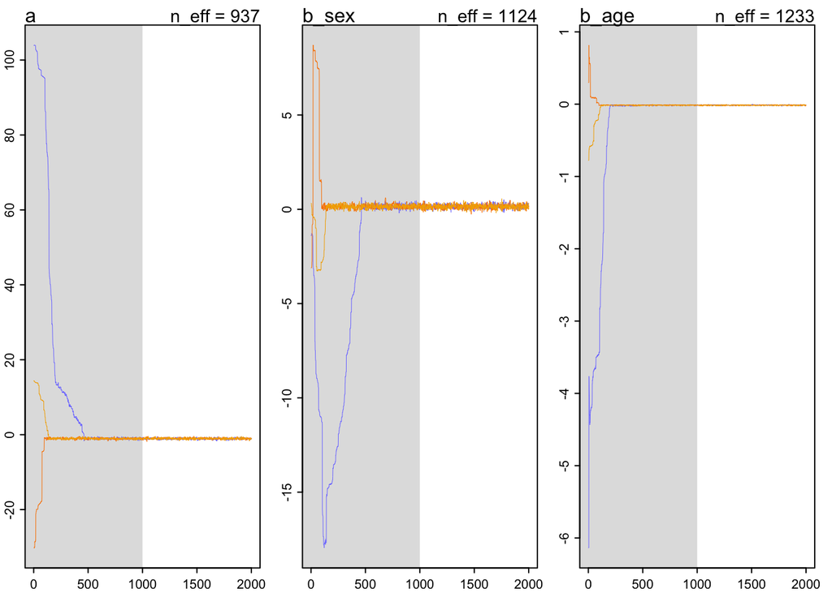

```r
plot(mr1)
```

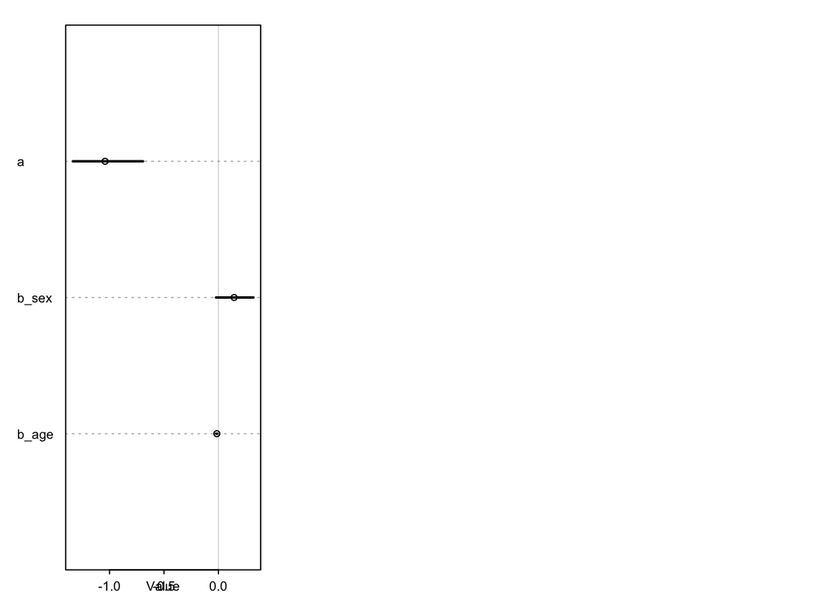

```r
plot(precis(mr1))

post_mr1_means <- as_tibble(as.list(coef(mr1))) %>% mutate_all(exp)
post_mr1_means <- post_mr1_means %>%
  mutate(rowname = "mean")

post_mr1 <- extract.samples(mr1, pars = c("a", "b_sex", "b_age"))

post_mr1_sum <- purrr::map(post_mr1, ~ PI(.x, prob = 0.89))
post_mr1_sum <- purrr::map(post_mr1_sum, ~ exp(.x))
post_mr1_sum <- data.frame(post_mr1_sum) %>% rownames_to_column()

post_mr1_sum <- bind_rows(post_mr1_sum, post_mr1_means) %>%
  mutate(model="mr1")
```

Men appear more likely to complete testing that women. And decrease in the probability of testing by age.

Model 2a - now add in cough of any duration.

```r
mr2a <- map2stan(
  alist(
    testedhiv2 ~ dbinom(1, p),
    logit(p) <- a + b_sex*sex2 + b_age*age + b_cough*cough2,
    a ~dnorm(0,100),
    b_sex ~ dnorm(0,2.5),
    b_age ~ dnorm(0,2.5),
    b_cough ~ dnorm(0,2.5)
    ),
  data=outdata, chains = 3)
```

```
## Computing WAIC
```

```
## Constructing posterior predictions
```

```
## [ 300 / 3000 ]
[ 600 / 3000 ]
[ 900 / 3000 ]
[ 1200 / 3000 ]
[ 1500 / 3000 ]
[ 1800 / 3000 ]
[ 2100 / 3000 ]
[ 2400 / 3000 ]
[ 2700 / 3000 ]
[ 3000 / 3000 ]
```

```r
precis(mr2a)
```

```
##          Mean StdDev lower 0.89 upper 0.89 n_eff Rhat
## a       -1.28   0.25      -1.68      -0.89  1145 1.00
## b_sex    0.14   0.11      -0.03       0.31  1401 1.01
## b_age   -0.02   0.00      -0.02      -0.01  2072 1.00
## b_cough  0.19   0.11       0.02       0.36  1419 1.00
```

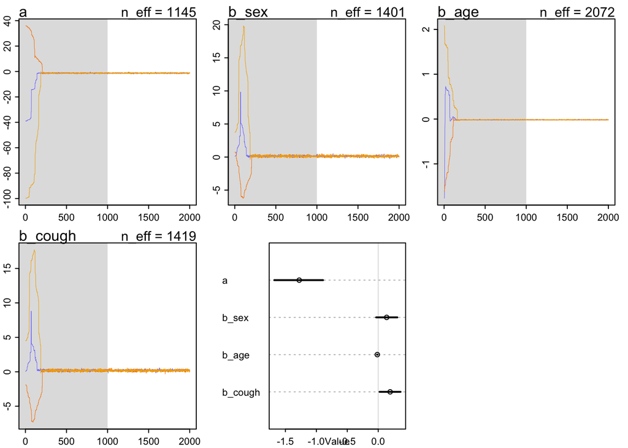

```r
plot(mr2a)
plot(precis(mr2a))

post_mr2a_means <- as_tibble(as.list(coef(mr2a))) %>% mutate_all(exp)
post_mr2a_means <- post_mr2a_means %>%
  mutate(rowname = "mean")

post_mr2a <- extract.samples(mr2a, pars = c("a", "b_sex", "b_age", "b_cough"))

post_mr2a_sum <- purrr::map(post_mr2a, ~ PI(.x, prob = 0.89))
post_mr2a_sum <- purrr::map(post_mr2a_sum, ~ exp(.x))
post_mr2a_sum <- data.frame(post_mr2a_sum) %>% rownames_to_column()

post_mr2a_sum <- bind_rows(post_mr2a_sum, post_mr2a_means) %>%
  mutate(model="mr2a")
```

As we would expect, individuals reporting cough of any duration had a greater posterior probability of completing HIV testing.

Model 2b - try adjusting for the effect of previous TB treatment

```r
mr2b <- map2stan(
  alist(
    testedhiv2 ~ dbinom(1, p),
    logit(p) <- a + b_sex*sex2 + b_age*age + b_cough*cough2 +
      b_prevtb*prevtb2,
    a ~dnorm(0,100),
    b_sex ~ dnorm(0,2.5),
    b_age ~ dnorm(0,2.5),
    b_cough ~ dnorm(0,2.5),
    b_prevtb ~ dnorm(0,2.5)),
  data=outdata, chains = 3)
```

```
## Computing WAIC
```

```
## Constructing posterior predictions
```

```
## [ 300 / 3000 ]
[ 600 / 3000 ]
[ 900 / 3000 ]
[ 1200 / 3000 ]
[ 1500 / 3000 ]
[ 1800 / 3000 ]
[ 2100 / 3000 ]
[ 2400 / 3000 ]
[ 2700 / 3000 ]
[ 3000 / 3000 ]
```

```r
precis(mr2b)
```

```
##           Mean StdDev lower 0.89 upper 0.89 n_eff Rhat
## a        -0.68   0.41      -1.33       0.01  1224    1
## b_sex     0.15   0.11      -0.02       0.34  1929    1
## b_age    -0.01   0.00      -0.02      -0.01  2940    1
## b_cough   0.20   0.11       0.02       0.37  2007    1
## b_prevtb -0.63   0.36      -1.17      -0.05  1373    1
```

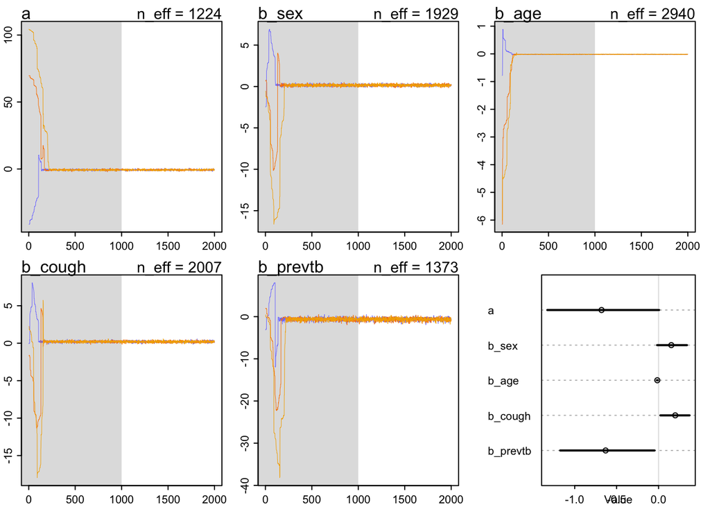

```r
plot(mr2b)
plot(precis(mr2b))
```

```r
post_mr2b_means <- as_tibble(as.list(coef(mr2b))) %>% mutate_all(exp)
post_mr2b_means <- post_mr2b_means %>%
  mutate(rowname = "mean")

post_mr2b <- extract.samples(mr2b, pars = c("a", "b_sex", "b_age", "b_cough",
                                            "b_prevtb"))

post_mr2b_sum <- purrr::map(post_mr2b, ~ PI(.x, prob = 0.89))
post_mr2b_sum <- purrr::map(post_mr2b_sum, ~ exp(.x))
post_mr2b_sum <- data.frame(post_mr2b_sum) %>% rownames_to_column()

post_mr2b_sum <- bind_rows(post_mr2b_sum, post_mr2b_means) %>%
  mutate(model="mr2b")
```

Model 2c - try adjusting for the effect of ever having previously tested for HIV

```r
mr2c <- map2stan(
  alist(
    testedhiv2 ~ dbinom(1, p),
    logit(p) <- a + b_sex*sex2 + b_age*age + b_cough*cough2 +
      b_prevtb*prevtb2 + b_everhivtest*everhivtest2,
    a ~dnorm(0,100),
    b_sex ~ dnorm(0,2.5),
    b_age ~ dnorm(0,2.5),
    b_cough ~ dnorm(0,2.5),
    b_prevtb ~ dnorm(0,2.5),
    b_everhivtest ~ dnorm(0,2.5)
    ),
  data=outdata, chains = 3)
```

```
## Computing WAIC
```

```
## Constructing posterior predictions
```

```
## [ 300 / 3000 ]
[ 600 / 3000 ]
[ 900 / 3000 ]
[ 1200 / 3000 ]
[ 1500 / 3000 ]
[ 1800 / 3000 ]
[ 2100 / 3000 ]
[ 2400 / 3000 ]
[ 2700 / 3000 ]
[ 3000 / 3000 ]
```

```r
precis(mr2c)
```

```
##                Mean StdDev lower 0.89 upper 0.89 n_eff Rhat
## a             -2.84   0.62      -3.81      -1.84  1592    1
## b_sex          0.21   0.11       0.04       0.39  3067    1
## b_age         -0.01   0.00      -0.02      -0.01  3218    1
## b_cough        0.21   0.11       0.04       0.39  2800    1
## b_prevtb      -0.70   0.35      -1.28      -0.18  2335    1
## b_everhivtest  1.11   0.24       0.73       1.47  1884    1
```

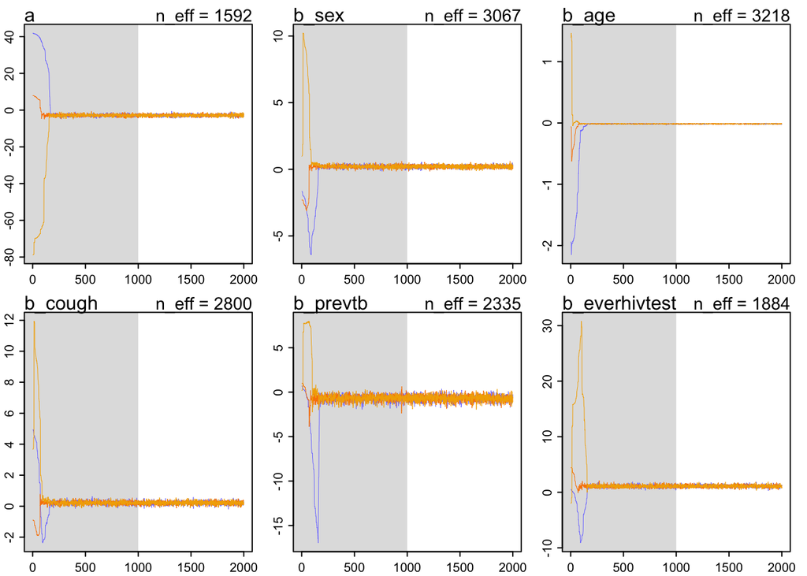

```r
plot(mr2c)
```

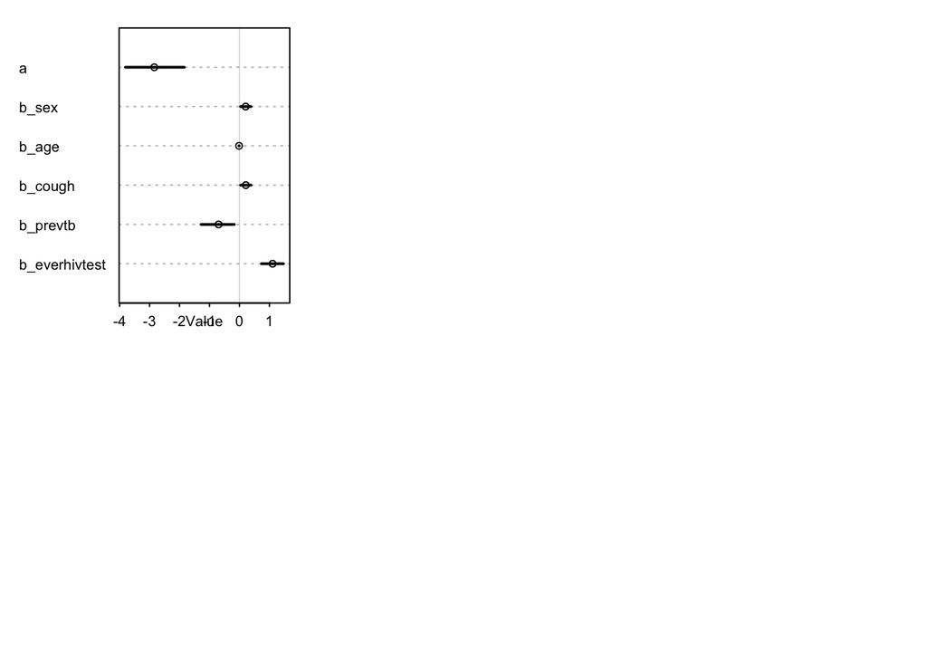

```r
plot(precis(mr2c))

post_mr2c_means <- as_tibble(as.list(coef(mr2c))) %>% mutate_all(exp)
post_mr2c_means <- post_mr2c_means %>%
  mutate(rowname = "mean")

post_mr2c <- extract.samples(mr2c, pars = c("a", "b_sex", "b_age", "b_cough",
                                            "b_prevtb", "b_everhivtest"))

post_mr2c_sum <- purrr::map(post_mr2c, ~ PI(.x, prob = 0.89))
post_mr2c_sum <- purrr::map(post_mr2c_sum, ~ exp(.x))
post_mr2c_sum <- data.frame(post_mr2c_sum) %>% rownames_to_column()

post_mr2c_sum <- bind_rows(post_mr2c_sum, post_mr2c_means) %>%
  mutate(model="mr2c")
```

Model 3 - what about chronic cough (>2 weeks - “classic” TB passive case finding symptom)

```r
mr3a <- map2stan(
  alist(
    testedhiv2 ~ dbinom(1, p),
    logit(p) <- a + b_sex*sex2 + b_age*age + b_chronic_cough*chronic_cough2,
    a ~dnorm(0,100),
    b_sex ~ dnorm(0,2.5),
    b_age ~ dnorm(0,2.5),
    b_chronic_cough ~ dnorm(0,2.5)),
  data=outdata, chains = 3)
```

```
## Computing WAIC
```

```
## Constructing posterior predictions
```

```
## [ 300 / 3000 ]
[ 600 / 3000 ]
[ 900 / 3000 ]
[ 1200 / 3000 ]
[ 1500 / 3000 ]
[ 1800 / 3000 ]
[ 2100 / 3000 ]
[ 2400 / 3000 ]
[ 2700 / 3000 ]
[ 3000 / 3000 ]
```

```r
precis(mr3a)
```

```
##                  Mean StdDev lower 0.89 upper 0.89 n_eff Rhat
## a               -1.04   0.21      -1.37      -0.70  1021    1
## b_sex            0.15   0.11      -0.02       0.33  1203    1
## b_age           -0.01   0.00      -0.02      -0.01  1801    1
## b_chronic_cough -0.20   0.21      -0.51       0.15  1691    1
```

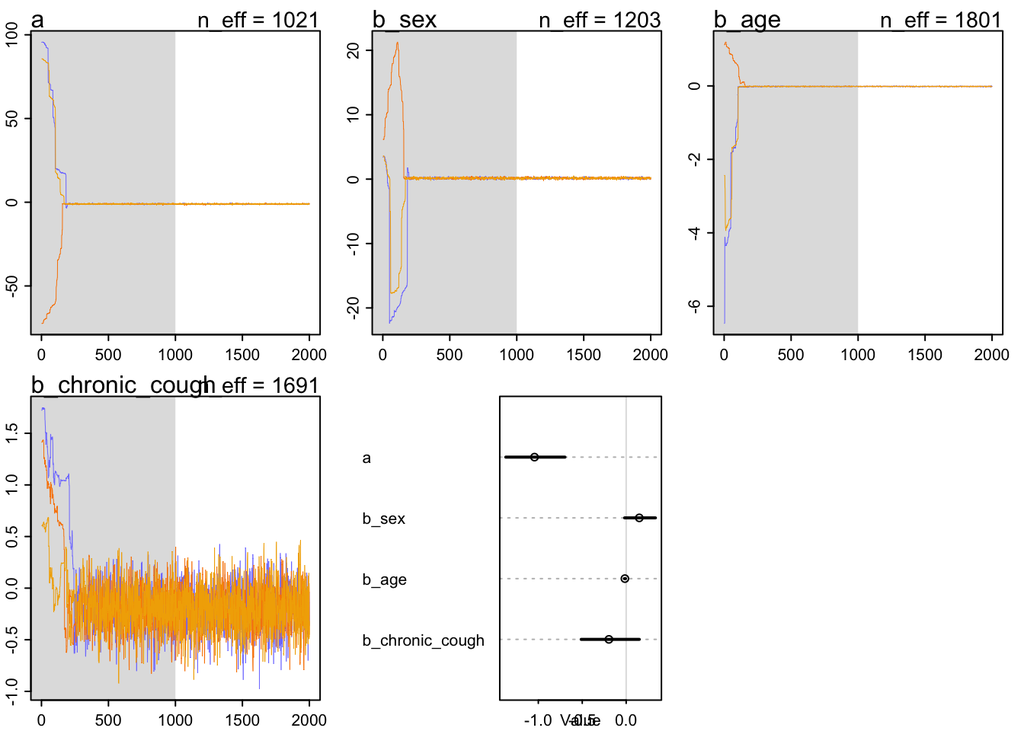

```r
plot(mr3a)
plot(precis(mr3a))

post_mr3a_means <- as_tibble(as.list(coef(mr3a))) %>% mutate_all(exp)
post_mr3a_means <- post_mr3a_means %>%
  mutate(rowname = "mean")

post_mr3a <- extract.samples(mr3a, pars = c("a", "b_sex", "b_age", "b_chronic_cough"))

post_mr3a_sum <- purrr::map(post_mr3a, ~ PI(.x, prob = 0.89))
post_mr3a_sum <- purrr::map(post_mr3a_sum, ~ exp(.x))
post_mr3a_sum <- data.frame(post_mr3a_sum) %>% rownames_to_column()

post_mr3a_sum <- bind_rows(post_mr3a_sum, post_mr3a_means) %>%
  mutate(model="mr3a")
```

Opposite pattern - individuals with chronic cough less likely to complete HIV testing. Might this be because they are taking TB treatment already (and so might have already been recently tested for HIV?)

```r
outdata %>%
  tabyl(chronic_cough2, prevtb) %>%
  adorn_totals("col") %>%
  adorn_totals("row") %>%
  adorn_percentages("col") %>%
  adorn_pct_formatting() %>%
  adorn_ns() %>%
  kable(digits = 3)
```

| chronic_cough2 | No | Yes | Total |
| --- | --- | --- | --- |
| 0 | 92.3% (1885) | 73.1% (57) | 91.6% (1942) |
| 1 | 7.7% (158) | 26.9% (21) | 8.4% (179) |
| Total | 100.0% (2043) | 100.0% (78) | 100.0% (2121) |

So looks like a strong relationship between previous tb and chronic cough.

Model 3b - Try adding in previous TB as a term.

```r
mr3b <- map2stan(
  alist(
    testedhiv2 ~ dbinom(1, p),
    logit(p) <- a + b_sex*sex2 + b_age*age + b_chronic_cough*chronic_cough2 +
      b_prevtb*prevtb2,
    a ~dnorm(0,100),
    b_sex ~ dnorm(0,2.5),
    b_age ~ dnorm(0,2.5),
    b_chronic_cough ~ dnorm(0,2.5),
    b_prevtb ~ dnorm(0,2.5)),
  data=outdata, chains = 3)
```

```
## Computing WAIC
```

```
## Constructing posterior predictions
```

```
## [ 300 / 3000 ]
[ 600 / 3000 ]
[ 900 / 3000 ]
[ 1200 / 3000 ]
[ 1500 / 3000 ]
[ 1800 / 3000 ]
[ 2100 / 3000 ]
[ 2400 / 3000 ]
[ 2700 / 3000 ]
[ 3000 / 3000 ]
```

```r
precis(mr3b)
```

```
##                  Mean StdDev lower 0.89 upper 0.89 n_eff Rhat
## a               -0.48   0.40      -1.13       0.13  1219    1
## b_sex            0.16   0.11      -0.01       0.33  2182    1
## b_age           -0.01   0.00      -0.02      -0.01  2269    1
## b_chronic_cough -0.17   0.21      -0.50       0.15  2537    1
## b_prevtb        -0.58   0.36      -1.08       0.08  1334    1
```

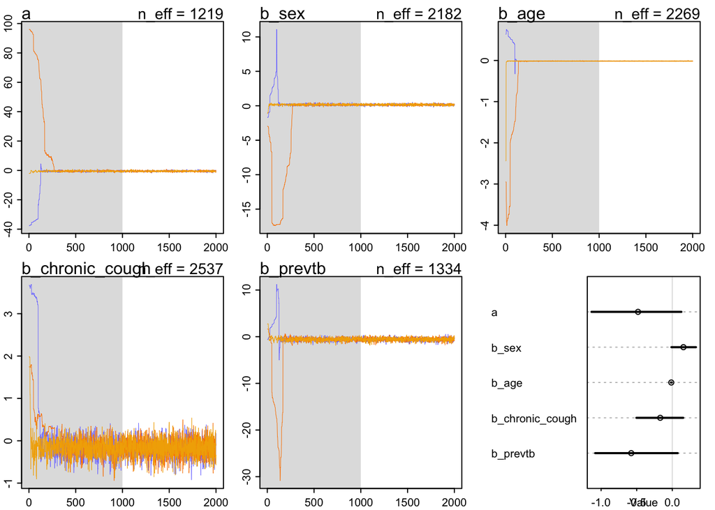

```r
plot(mr3b)
plot(precis(mr3b))
```

```r
post_mr3b_means <- as_tibble(as.list(coef(mr3b))) %>% mutate_all(exp)
post_mr3b_means <- post_mr3b_means %>%
  mutate(rowname = "mean")

post_mr3b <- extract.samples(mr3b, pars = c("a", "b_sex", "b_age", "b_chronic_cough",
                                            "b_prevtb"))

post_mr3b_sum <- purrr::map(post_mr3b, ~ PI(.x, prob = 0.89))
post_mr3b_sum <- purrr::map(post_mr3b_sum, ~ exp(.x))
post_mr3b_sum <- data.frame(post_mr3b_sum) %>% rownames_to_column()

post_mr3b_sum <- bind_rows(post_mr3b_sum, post_mr3b_means) %>%
  mutate(model="mr3b")
```

Model 3c - add in ever previously tested for HIV

```r
mr3c <- map2stan(
  alist(
    testedhiv2 ~ dbinom(1, p),
    logit(p) <- a + b_sex*sex2 + b_age*age + b_chronic_cough*chronic_cough2 +
      b_prevtb*prevtb2 + b_everhivtest*everhivtest2,
    a ~dnorm(0,100),
    b_sex ~ dnorm(0,2.5),
    b_age ~ dnorm(0,2.5),
    b_chronic_cough ~ dnorm(0,2.5),
    b_prevtb ~ dnorm(0,2.5),
    b_everhivtest ~ dnorm(0,2.5)
    ),
  data=outdata, chains = 3)
```

```
## Computing WAIC
```

```
## Constructing posterior predictions
```

```
## [ 300 / 3000 ]
[ 600 / 3000 ]
[ 900 / 3000 ]
[ 1200 / 3000 ]
[ 1500 / 3000 ]
[ 1800 / 3000 ]
[ 2100 / 3000 ]
[ 2400 / 3000 ]
[ 2700 / 3000 ]
[ 3000 / 3000 ]
```

```r
precis(mr3c)
```

```
##                  Mean StdDev lower 0.89 upper 0.89 n_eff Rhat
## a               -2.60   0.62      -3.62      -1.64  1576    1
## b_sex            0.22   0.11       0.03       0.39  2238    1
## b_age           -0.01   0.00      -0.02      -0.01  3127    1
## b_chronic_cough -0.17   0.22      -0.50       0.20  3038    1
## b_prevtb        -0.65   0.37      -1.22      -0.06  2009    1
## b_everhivtest    1.09   0.24       0.73       1.51  1920    1
```

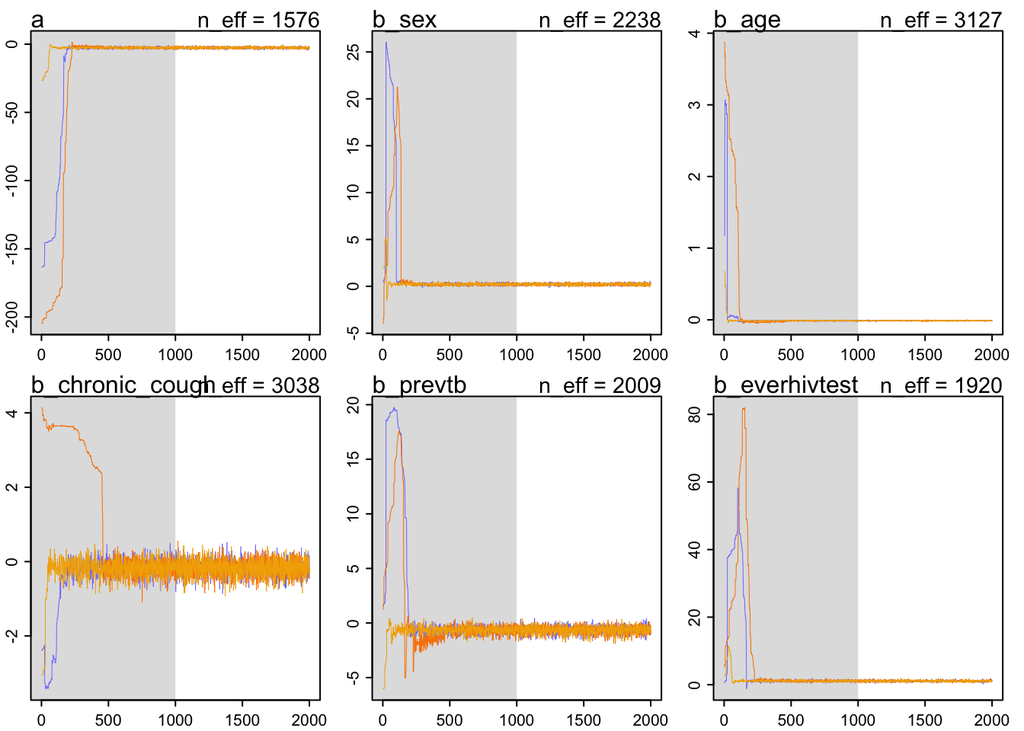

```r
plot(mr3c)
```

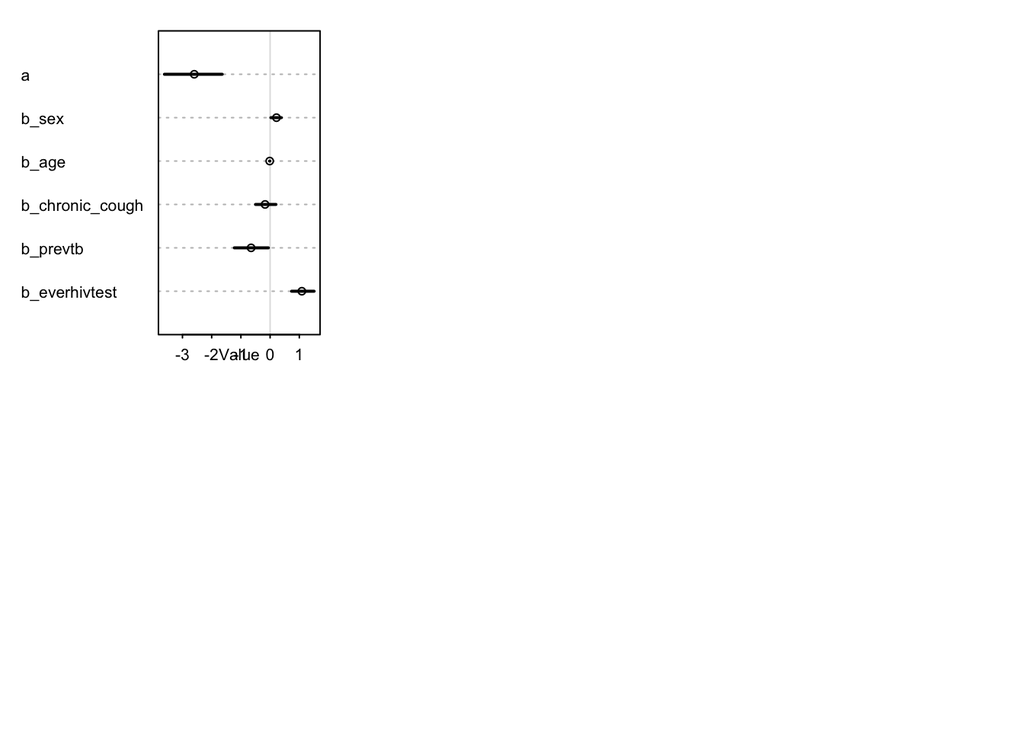

```r
plot(precis(mr3c))

post_mr3c_means <- as_tibble(as.list(coef(mr3c))) %>% mutate_all(exp)
post_mr3c_means <- post_mr3c_means %>%
  mutate(rowname = "mean")

post_mr3c <- extract.samples(mr3c, pars = c("a", "b_sex", "b_age", "b_chronic_cough",
                                            "b_prevtb", "b_everhivtest"))

post_mr3c_sum <- purrr::map(post_mr3c, ~ PI(.x, prob = 0.89))
post_mr3c_sum <- purrr::map(post_mr3c_sum, ~ exp(.x))
post_mr3c_sum <- data.frame(post_mr3c_sum) %>% rownames_to_column()

post_mr3c_sum <- bind_rows(post_mr3c_sum, post_mr3c_means) %>%
  mutate(model="mr3c")
```

Model 4a - what about individuals with any symptoms of TB (cough, fever, weight loss, or night sweats)

```r
mr4a <- map2stan(
  alist(
    testedhiv2 ~ dbinom(1, p),
    logit(p) <- a + b_sex*sex2 + b_age*age + b_anysymptoms*any_symptoms2,
    a ~dnorm(0,100),
    b_sex ~ dnorm(0,2.5),
    b_age ~ dnorm(0,2.5),
    b_anysymptoms ~ dnorm(0,2.5)),
  data=outdata, chains = 3)
```

```
## Computing WAIC
```

```
## Constructing posterior predictions
```

```
## [ 300 / 3000 ]
[ 600 / 3000 ]
[ 900 / 3000 ]
[ 1200 / 3000 ]
[ 1500 / 3000 ]
[ 1800 / 3000 ]
[ 2100 / 3000 ]
[ 2400 / 3000 ]
[ 2700 / 3000 ]
[ 3000 / 3000 ]
```

```r
precis(mr4a)
```

```
##                Mean StdDev lower 0.89 upper 0.89 n_eff Rhat
## a             -0.88   0.25      -1.26      -0.46  1474    1
## b_sex          0.14   0.11      -0.03       0.31  1908    1
## b_age         -0.02   0.00      -0.02      -0.01  2166    1
## b_anysymptoms -0.10   0.10      -0.26       0.06  1757    1
```

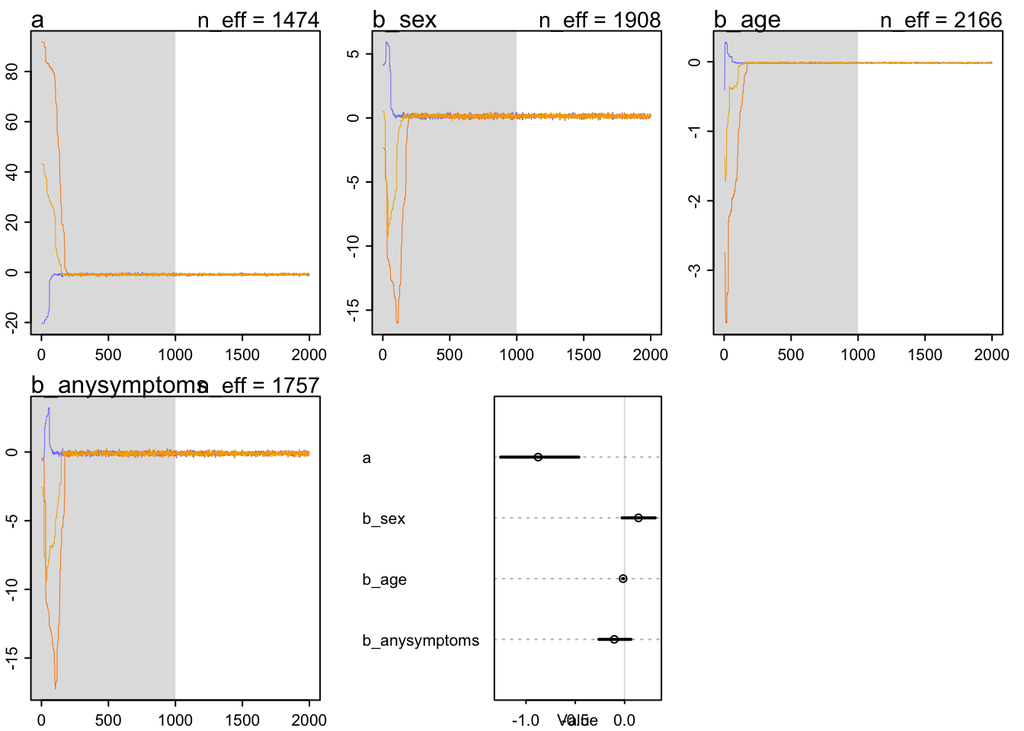

```r
plot(mr4a)
plot(precis(mr4a))

post_mr4a_means <- as_tibble(as.list(coef(mr4a))) %>% mutate_all(exp)
post_mr4a_means <- post_mr4a_means %>%
  mutate(rowname = "mean")

post_mr4a <- extract.samples(mr4a, pars = c("a", "b_sex", "b_age", "b_anysymptoms"))

post_mr4a_sum <- purrr::map(post_mr4a, ~ PI(.x, prob = 0.89))
post_mr4a_sum <- purrr::map(post_mr4a_sum, ~ exp(.x))
post_mr4a_sum <- data.frame(post_mr4a_sum) %>% rownames_to_column()

post_mr4a_sum <- bind_rows(post_mr4a_sum, post_mr4a_means) %>%
  mutate(model="mr4a")
```

Model 4b - add in previous TB

```r
mr4b <- map2stan(
  alist(
    testedhiv2 ~ dbinom(1, p),
    logit(p) <- a + b_sex*sex2 + b_age*age + b_anysymptoms*any_symptoms2 +
      b_prevtb*prevtb2,
    a ~dnorm(0,100),
    b_sex ~ dnorm(0,2.5),
    b_age ~ dnorm(0,2.5),
    b_anysymptoms ~ dnorm(0,2.5),
    b_prevtb ~ dnorm(0,2.5)
    ),
  data=outdata, chains = 3)
```

```
## Computing WAIC
```

```
## Constructing posterior predictions
```

```
## [ 300 / 3000 ]
[ 600 / 3000 ]
[ 900 / 3000 ]
[ 1200 / 3000 ]
[ 1500 / 3000 ]
[ 1800 / 3000 ]
[ 2100 / 3000 ]
[ 2400 / 3000 ]
[ 2700 / 3000 ]
[ 3000 / 3000 ]
```

```r
precis(mr4b)
```

```
##                Mean StdDev lower 0.89 upper 0.89 n_eff Rhat
## a             -0.27   0.43      -1.01       0.37  1207    1
## b_sex          0.16   0.11       0.00       0.33  1898    1
## b_age         -0.01   0.00      -0.02      -0.01  2818    1
## b_anysymptoms -0.11   0.11      -0.28       0.07  1644    1
## b_prevtb      -0.62   0.34      -1.16      -0.09  1525    1
```

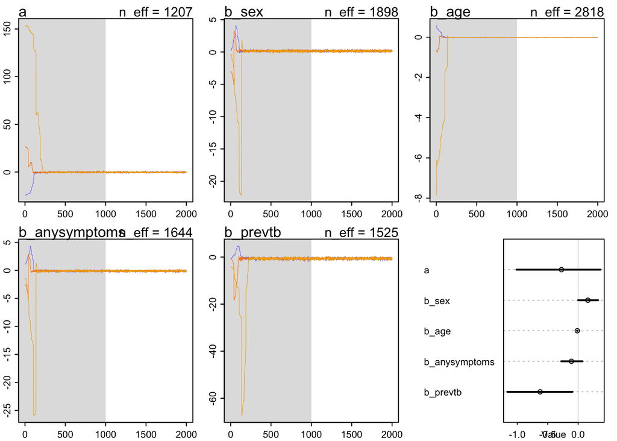

```r
plot(mr4b)
plot(precis(mr4b))
```

```r
post_mr4b_means <- as_tibble(as.list(coef(mr4b))) %>% mutate_all(exp)
post_mr4b_means <- post_mr4b_means %>%
  mutate(rowname = "mean")

post_mr4b <- extract.samples(mr4b, pars = c("a", "b_sex", "b_age", "b_anysymptoms",
                                            "b_prevtb"))

post_mr4b_sum <- purrr::map(post_mr4b, ~ PI(.x, prob = 0.89))
post_mr4b_sum <- purrr::map(post_mr4b_sum, ~ exp(.x))
post_mr4b_sum <- data.frame(post_mr4b_sum) %>% rownames_to_column()

post_mr4b_sum <- bind_rows(post_mr4b_sum, post_mr4b_means) %>%
  mutate(model="mr4b")
```

Model 4c - add in ever previously HIV tested

```r
mr4c <- map2stan(
  alist(
    testedhiv2 ~ dbinom(1, p),
    logit(p) <- a + b_sex*sex2 + b_age*age + b_anysymptoms*any_symptoms2 +
      b_prevtb*prevtb2 + b_everhivtest*everhivtest2,
    a ~dnorm(0,100),
    b_sex ~ dnorm(0,2.5),
    b_age ~ dnorm(0,2.5),
    b_anysymptoms ~ dnorm(0,2.5),
    b_prevtb ~ dnorm(0,2.5),
    b_everhivtest ~ dnorm(0,2.5)
    ),
  data=outdata, chains = 3)
```

```
## Computing WAIC
```

```
## Constructing posterior predictions
```

```
## [ 300 / 3000 ]
[ 600 / 3000 ]
[ 900 / 3000 ]
[ 1200 / 3000 ]
[ 1500 / 3000 ]
[ 1800 / 3000 ]
[ 2100 / 3000 ]
[ 2400 / 3000 ]
[ 2700 / 3000 ]
[ 3000 / 3000 ]
```

```r
precis(mr4c)
```

```
##                Mean StdDev lower 0.89 upper 0.89 n_eff Rhat
## a             -2.40   0.62      -3.36      -1.36  1631    1
## b_sex          0.21   0.11       0.05       0.38  2950    1
## b_age         -0.01   0.00      -0.02      -0.01  3563    1
## b_anysymptoms -0.13   0.11      -0.30       0.05  2781    1
## b_prevtb      -0.68   0.35      -1.20      -0.10  2465    1
## b_everhivtest  1.11   0.23       0.73       1.48  1771    1
```

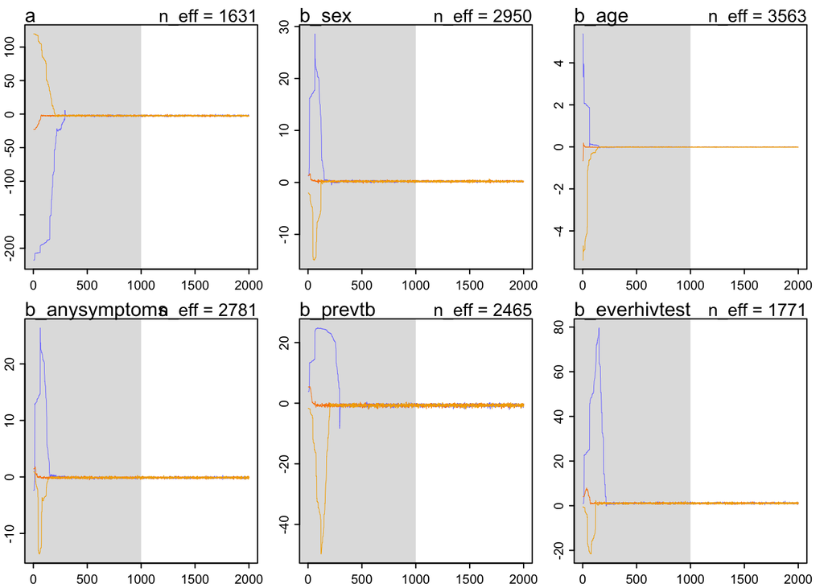

```r
plot(mr4c)
```

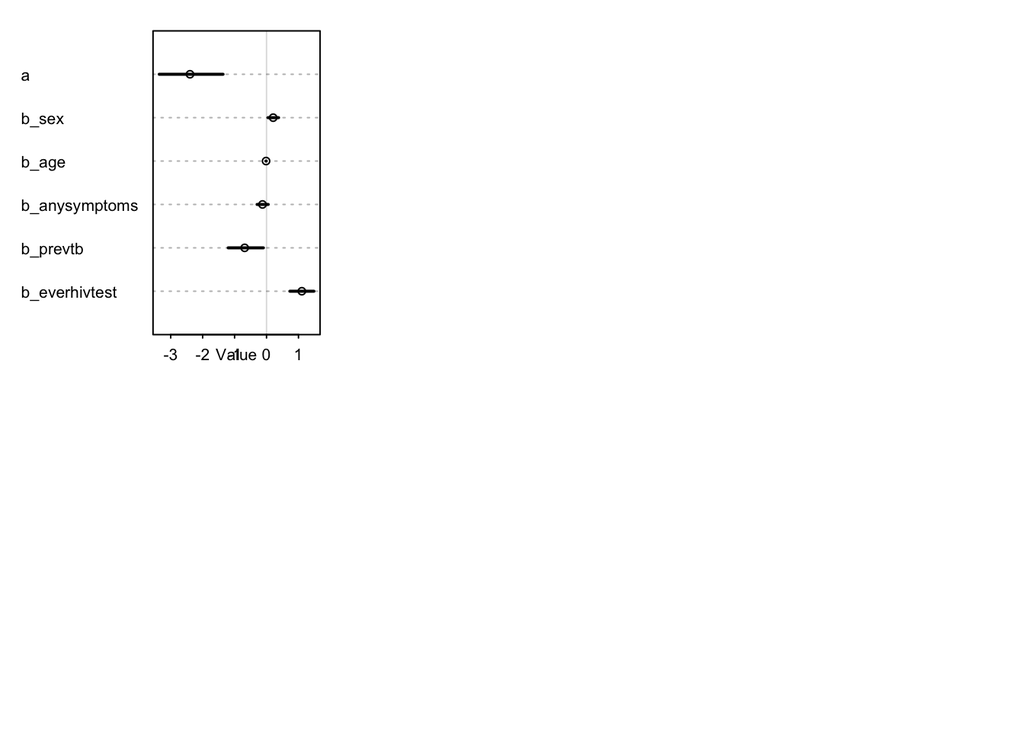

```r
plot(precis(mr4c))

post_mr4c_means <- as_tibble(as.list(coef(mr4c))) %>% mutate_all(exp)
post_mr4c_means <- post_mr4c_means %>%
  mutate(rowname = "mean")

post_mr4c <- extract.samples(mr4c, pars = c("a", "b_sex", "b_age", "b_anysymptoms",
                                            "b_prevtb", "b_everhivtest"))

post_mr4c_sum <- purrr::map(post_mr4c, ~ PI(.x, prob = 0.89))
post_mr4c_sum <- purrr::map(post_mr4c_sum, ~ exp(.x))
post_mr4c_sum <- data.frame(post_mr4c_sum) %>% rownames_to_column()

post_mr4c_sum <- bind_rows(post_mr4c_sum, post_mr4c_means) %>%
  mutate(model="mr4c")
```

Compare the models by estimating their WAIC statistics and weights

```r
rethinking::compare(mr1, mr2a, mr2b, mr2c, mr3a, mr3b, mr3c, mr4a, mr4b, mr4c)
```

```
##        WAIC pWAIC dWAIC weight    SE   dSE
## mr2c 2169.7   6.0   0.0   0.66 49.80    NA
## mr4c 2171.9   5.9   2.2   0.22 49.78  2.89
## mr3c 2173.2   6.2   3.5   0.12 49.75  4.72
## mr2b 2193.6   5.0  23.9   0.00 49.54  9.52
## mr2a 2194.9   3.9  25.2   0.00 49.44 10.33
## mr4b 2195.7   4.9  26.0   0.00 49.60  9.97
## mr1  2196.0   2.9  26.3   0.00 49.42 10.78
## mr3b 2196.7   5.2  26.9   0.00 49.55 10.52
## mr4a 2196.9   3.8  27.2   0.00 49.44 10.67
## mr3a 2197.3   4.0  27.6   0.00 49.46 11.12
```

So models 2c, 3c and 4c have the lowest WAIC and the greatest weights. Essentially, none of the other models have any weight.

Figure 2: Now plot the posterior distributions

```r
#A table of summaries of posteior distributions

bind_rows(post_mr1_sum,
          post_mr2a_sum, post_mr2b_sum, post_mr2c_sum,
          post_mr3a_sum, post_mr3b_sum, post_mr3c_sum,
          post_mr4a_sum, post_mr4b_sum, post_mr4c_sum)
```

```
##    rowname          a     b_sex     b_age model  b_cough  b_prevtb
## 1       5% 0.25255976 0.9706445 0.9784787   mr1       NA        NA
## 2      94% 0.48684552 1.3717974 0.9919537   mr1       NA        NA
## 3     mean 0.35317473 1.1544031 0.9852542   mr1       NA        NA
## 4       5% 0.18843352 0.9657969 0.9782714  mr2a 1.021204        NA
## 5      94% 0.41935589 1.3608813 0.9910430  mr2a 1.434642        NA
## 6     mean 0.27901864 1.1457577 0.9848148  mr2a 1.212217        NA
## 7       5% 0.26495530 0.9738275 0.9789976  mr2b 1.026667 0.2899015
## 8      94% 1.00490573 1.3911789 0.9920585  mr2b 1.457369 0.9113849
## 9     mean 0.50679699 1.1642960 0.9854635  mr2b 1.220778 0.5320352
## 10      5% 0.02239809 1.0297207 0.9787505  mr2c 1.037223 0.2789668
## 11     94% 0.16032158 1.4604210 0.9924037  mr2c 1.468601 0.8408146
## 12    mean 0.05821656 1.2287033 0.9856559  mr2c 1.237056 0.4979595
## 13      5% 0.25164423 0.9763626 0.9786174  mr3a       NA        NA
## 14     94% 0.49560198 1.3885256 0.9924381  mr3a       NA        NA
```

[output cut: 47 more lines]

```r
gdata <- bind_rows(post_mr2c_sum, post_mr3c_sum, post_mr4c_sum) %>%
  select(model, everything()) %T>%
  print %>%
  gather(parameter, value, -model, -rowname) %>%
  mutate(parameter = case_when(parameter=="b_age" ~ "Age (years)",
                               parameter=="b_sex" ~ "Male sex",
                               parameter=="b_prevtb" ~ "Previous TB",
                               parameter=="b_everhivtest" ~ "Previous HIV test",
                               parameter=="b_cough" ~ "Cough",
                               parameter=="b_chronic_cough" ~ "Chronic cough",
                               parameter=="b_anysymptoms" ~ "Any TB symptoms",
                               parameter=="a" ~ "Intercept")) %>%
  mutate(parameter = factor(parameter)) %>%
  mutate(parameter = fct_relevel(parameter,
                                 "Intercept",
                                 "Any TB symptoms",
                                 "Chronic cough",
                                 "Cough",
                                 "Previous HIV test",
                                 "Previous TB",
                                 "Male sex",
                                 "Age (years)"
                                 ))
```

```
##   model rowname          a    b_sex     b_age  b_cough  b_prevtb
## 1  mr2c      5% 0.02239809 1.029721 0.9787505 1.037223 0.2789668
## 2  mr2c     94% 0.16032158 1.460421 0.9924037 1.468601 0.8408146
## 3  mr2c    mean 0.05821656 1.228703 0.9856559 1.237056 0.4979595
## 4  mr3c      5% 0.02782101 1.036221 0.9797073       NA 0.2772272
## 5  mr3c     94% 0.20240655 1.486822 0.9933169       NA 0.9065770
## 6  mr3c    mean 0.07451085 1.243175 0.9866165       NA 0.5219387
## 7  mr4c      5% 0.03281376 1.047597 0.9792846       NA 0.2836167
## 8  mr4c     94% 0.24416159 1.460337 0.9925051       NA 0.8581365
## 9  mr4c    mean 0.09105710 1.231257 0.9858854       NA 0.5044928
##   b_everhivtest b_chronic_cough b_anysymptoms
## 1      2.106435              NA            NA
## 2      4.434847              NA            NA
## 3      3.022869              NA            NA
## 4      2.048789       0.5838277            NA
## 5      4.455467       1.1836799            NA
## 6      2.964103       0.8419746            NA
## 7      2.074732              NA     0.7425761
## 8      4.406740              NA     1.0541969
## 9      3.019749              NA     0.8815953
```

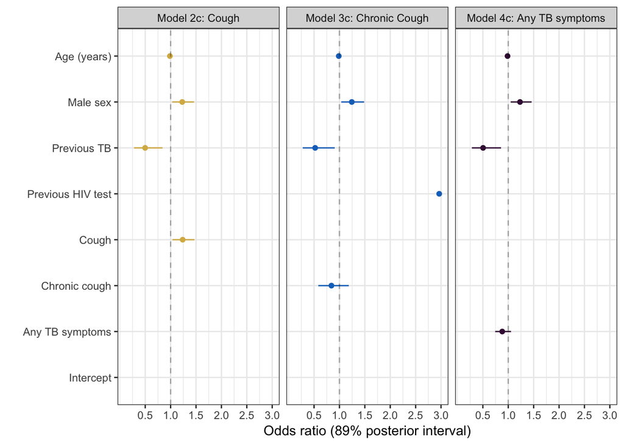

```r
gdata_means <- gdata %>%
  filter(rowname=="mean")

gdata_ranges <- gdata %>%
  filter(rowname !="mean") %>%
  spread(rowname, value) %>%
  select(everything(), l = `5%`, h = `94%`)

glabels <- c(
  mr2c = "Model 2c: Cough",
  mr3c = "Model 3c: Chronic Cough",
  mr4c = "Model 4c: Any TB symptoms"
)

ggplot() +
  geom_point(data=gdata_means, aes(x=value, y=parameter, colour=model)) +
  geom_segment(data=gdata_ranges, aes(y=parameter, yend=parameter, x=l, xend=h, colour=model)) +
  geom_vline(data=gdata, aes(xintercept=1), alpha=0.3, linetype="dashed") +
  facet_wrap(~model,
             labeller = labeller(model=glabels)) +
  scale_color_rail(palette="penzance") +
  scale_x_continuous(limits = c(0.1,3.0), breaks = c(0.5,1.0,1.5,2.0,2.5,3.0)) +
  theme_bw() +
  ylab("") +
  xlab("Odds ratio (89% posterior interval)") +
  theme(legend.position="none")
```

```r
ggsave(file="fig2.png", width = 8, height = 6, dpi=300,
       path = here::here("figures"))
```

Posterior predictions for age and sex for each model

```r
outdata <- outdata %>%
  mutate(chronic_cough2 = factor(chronic_cough2)) %>%
  mutate(any_symptoms2 = factor(any_symptoms2))


prior <- c(prior_string("normal(0,2.5)", class="b"),
           prior_(~normal(0,100), class= ~Intercept))

graph2c <- brm(bf(testedhiv2 ~
          sex +
          age +
          cough +
          prevtb +
          everhivtest),
          data=outdata,
          family='bernoulli',
          prior = prior,
          iter=1000, warmup=500,
          chains=3,
          seed=1234)
g2c <- plot_model(graph2c, type = "pred", terms = c("age", "sex"),
                 title = "Model 2c: Cough",
                 axis.title = c("Age (years)", "Probability of HIV testing (89% interval)"),
           legend.title = "Sex",
           ci.lvl = 0.89,
           colors = c("steelblue", "firebrick"),
           show.legend = FALSE)

g2c <- g2c + theme_bw() + ylim(0,0.35) + scale_y_continuous(labels=scales::percent_format())
graph3c <- brm(bf(testedhiv2 ~
          sex +
          age +
          chronic_cough2 +
          prevtb +
          everhivtest),
          data=outdata,
          family='bernoulli',
          prior = prior,
          iter=1000, warmup=500,
          chains=3,
          seed=1234)
```

```
## recompiling to avoid crashing R session
```

```r
g3c <- plot_model(graph3c, type = "pred", terms = c("age", "sex"),
                 title = "Model 3c: Chronic cough",
                 axis.title = c("Age (years)", ""),
           legend.title = "Sex",
           ci.lvl = 0.89,
           colors = c("steelblue", "firebrick"),
           show.legend = FALSE)

g3c <- g3c + theme_bw() + ylim(0,0.35)+ scale_y_continuous(labels=scales::percent_format())
graph4c <- brm(bf(testedhiv2 ~
          sex +
          age +
          any_symptoms2 +
          prevtb +
          everhivtest),
          data=outdata,
          family='bernoulli',
          prior = prior,
          iter=1000, warmup=500,
          chains=3,
          seed=1234)
```

```
## recompiling to avoid crashing R session
```

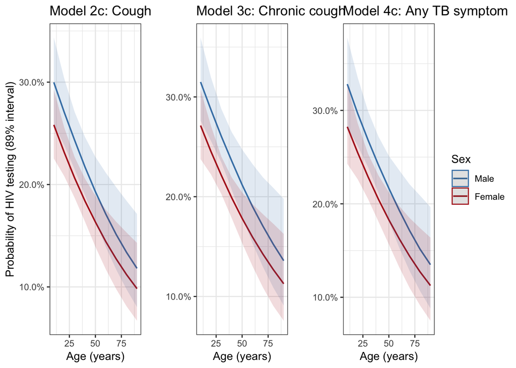

```r
g4c <- plot_model(graph4c, type = "pred", terms = c("age", "sex"),
                 title = "Model 4c: Any TB symptom",
                 axis.title = c("Age (years)", ""),
           legend.title = "Sex",
           ci.lvl = 0.89,
           colors = c("steelblue", "firebrick"))

g4c <- g4c + theme_bw() + ylim(0,0.35) + scale_y_continuous(labels=scales::percent_format())
library(patchwork)
g2c + g3c + g4c + plot_layout(ncol = 3)
```

```r
ggsave(file="fig3.png", width = 10, height = 6, dpi=300,
       path = here::here("figures"))
```

## 8. Reproducibility

This reproduction of the analysis was run by:

| keyName | value |
| --- | --- |
| sysname | Darwin |
| release | 18.5.0 |
| version | Darwin Kernel Version 18.5.0: Mon Mar 11 20:40:32 PDT 2019; root:xnu-4903.251.3~3/RELEASE_X86_64 |
| nodename | petermacphersons-MacBook-Pro.local |
| machine | x86_64 |
| login | peter.macpherson |
| user | peter.macpherson |
| effective_user | peter.macpherson |

Analysis was run at **2019-05-24 13:34:13**, and using the following Session Info:

```
R version 3.6.0 (2019-04-26)
Platform: x86_64-apple-darwin15.6.0 (64-bit)
Running under: macOS Mojave 10.14.4

Matrix products: default
BLAS:   /Library/Frameworks/R.framework/Versions/3.6/Resources/lib/libRblas.0.dylib
LAPACK: /Library/Frameworks/R.framework/Versions/3.6/Resources/lib/libRlapack.dylib

locale:
[1] en_GB.UTF-8/en_GB.UTF-8/en_GB.UTF-8/C/en_GB.UTF-8/en_GB.UTF-8

attached base packages:
[1] parallel  stats     graphics  grDevices utils     datasets  methods
[8] base

other attached packages:
 [1] patchwork_0.0.1         sjPlot_2.6.3
 [3] brms_2.8.0              Rcpp_1.0.1
 [5] arsenal_3.1.0           hiv.prospect_0.0.0.9000
 [7] rethinking_1.59         rstan_2.18.2
 [9] StanHeaders_2.18.1      knitr_1.23
[11] pmthemes_0.0.0.9000     janitor_1.2.0
[13] forcats_0.4.0           stringr_1.4.0
[15] dplyr_0.8.1             purrr_0.3.2
[17] readr_1.3.1             tidyr_0.8.3
[19] tibble_2.1.1            ggplot2_3.1.1
[21] tidyverse_1.2.1

loaded via a namespace (and not attached):
  [1] readxl_1.3.1         backports_1.1.4      plyr_1.8.4
  [4] igraph_1.2.4.1       lazyeval_0.2.2       TMB_1.7.15
  [7] splines_3.6.0        crosstalk_1.0.0      rstantools_1.5.1
 [10] inline_0.3.15        digest_0.6.19        htmltools_0.3.6
 [13] rsconnect_0.8.13     fansi_0.4.0          magrittr_1.5
 [16] modelr_0.1.4         matrixStats_0.54.0   xts_0.11-2
 [19] prettyunits_1.0.2    colorspace_1.4-1     rvest_0.3.4
 [22] haven_2.1.0          xfun_0.7             callr_3.2.0
 [25] crayon_1.3.4         jsonlite_1.6         lme4_1.1-21
 [28] zeallot_0.1.0        survival_2.44-1.1    zoo_1.8-5
 [31] glue_1.3.1           gtable_0.3.0         emmeans_1.3.4
 [34] sjstats_0.17.4       sjmisc_2.7.9         pkgbuild_1.0.3
 [37] abind_1.4-5          scales_1.0.0         mvtnorm_1.0-10
 [40] ggeffects_0.10.0     miniUI_0.1.1.1       xtable_1.8-4
 [43] performance_0.1.0    foreign_0.8-71       stats4_3.6.0
 [46] DT_0.6               htmlwidgets_1.3      httr_1.4.0
 [49] threejs_0.3.1        pkgconfig_2.0.2      loo_2.1.0
 [52] here_0.1             utf8_1.1.4           labeling_0.3
 [55] tidyselect_0.2.5     rlang_0.3.4          reshape2_1.4.3
 [58] later_0.8.0          munsell_0.5.0        cellranger_1.1.0
 [61] tools_3.6.0          cli_1.1.0            generics_0.0.2
 [64] sjlabelled_1.0.17    broom_0.5.2          ggridges_0.5.1
 [67] evaluate_0.13        yaml_2.2.0           processx_3.3.1
 [70] nlme_3.1-140         mime_0.6             xml2_1.2.0
 [73] compiler_3.6.0       bayesplot_1.6.0      shinythemes_1.1.2
 [76] rstudioapi_0.10      testthat_2.1.1       stringi_1.4.3
 [79] highr_0.8            ps_1.3.0             Brobdingnag_1.2-6
 [82] lattice_0.20-38      Matrix_1.2-17        psych_1.8.12
 [85] nloptr_1.2.1         markdown_0.9         shinyjs_1.0
 [88] vctrs_0.1.0          pillar_1.4.0         bridgesampling_0.6-0
 [91] estimability_1.3     insight_0.3.0        httpuv_1.5.1
 [94] R6_2.4.0             promises_1.0.1       gridExtra_2.3
 [97] codetools_0.2-16     boot_1.3-22          colourpicker_1.0
[100] MASS_7.3-51.4        gtools_3.8.1         assertthat_0.2.1
[103] rprojroot_1.3-2      withr_2.1.2          shinystan_2.5.0
[106] mnormt_1.5-5         bayestestR_0.1.0     hms_0.4.2
[109] grid_3.6.0           coda_0.19-2          glmmTMB_0.2.3
[112] minqa_1.2.4          rmarkdown_1.12       snakecase_0.10.0
[115] shiny_1.3.2          lubridate_1.7.4      base64enc_0.1-3
[118] dygraphs_1.1.1.6
```